# Predicting Energy Star Score of Buildings

Saurabh

# 1 Problem Statement:

**Build the right model to predict the “Energy Star score” of a building ‘s using the provided data.**

## 1.1 Execuitive Summary

The NYC Benchmarking Law requires owners of large buildings to annually measure their energy and water consumption in a process called benchmarking. The law standardizes this process by requiring building owners to enter their annual energy and water use in the U.S. Environmental Protection Agency’s (EPA) online tool, Energy Star Portfolio Manager and use the tool to submit data. This data informs building owners about a building’s energy and water consumption compared to similar buildings, and tracks progress year over year to help in energy efficiency planning

An energy efficiency score is the Energy Star Rating that a building earns using the United States Environmental Protection Agency online benchmarking tool, Energy Star Portfolio Manager, to compare building energy performance to similar buildings in similar climates.

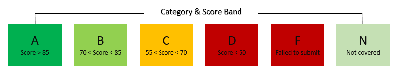

# 2 My thought process

After going through the entire assignment I choose to work upon this problem as I am confident to complete this within the given timeframe of 2 days and also this problem will allow me to demonstrate my capabilities in a better way, which probably will also be advantageous for the team to decide upon my candidature.

**My first objective is to get a good understanding of the dataset followed by exploratory data analysis, data sanity check, feature engineering, feature selection, model selection, stacking, scoring and any future work if required.**

**I will be highlighting all important notes and points wherever required, just like the way this line is highlighted**

Lets deep dive and see whats there in the Data.

# 3 Loading and Exploring Data

## 3.1 Loading required libraries

Loading R packages used besides base R.

```r
library(knitr)
library(ggplot2)
library(plyr)
library(dplyr)
library(caret)
library(gridExtra)
library(scales)
library(randomForest)
library(psych)
library(xgboost)
library(readr)
library(data.table)
library(DT)
library(DataExplorer)
```

## 3.2 Loading the dataset

```r
setwd("C:/Users/sysadmin/Downloads/Assignment/")
raw_data<-read_csv("Usecase1_Dataset.csv")
DT::datatable(head(raw_data,100))
```

|  | Order | Property Id | Property Name | Parent Property Id | Parent Property Name | BBL - 10 digits | NYC Borough, Block and Lot (BBL) self-reported | NYC Building Identification Number (BIN) | Address 1 (self-reported) | Address 2 | Postal Code | Street Number | Street Name | Borough | DOF Gross Floor Area | Primary Property Type - Self Selected | List of All Property Use Types at Property | Largest Property Use Type | Largest Property Use Type - Gross Floor Area (ft²) | 2nd Largest Property Use Type | 2nd Largest Property Use - Gross Floor Area (ft²) | 3rd Largest Property Use Type | 3rd Largest Property Use Type - Gross Floor Area (ft²) | Year Built | Number of Buildings - Self-reported | Occupancy | Metered Areas (Energy) | Metered Areas (Water) | ENERGY STAR Score | … |
| --- | --- | --- | --- | --- | --- | --- | --- | --- | --- | --- | --- | --- | --- | --- | --- | --- | --- | --- | --- | --- | --- | --- | --- | --- | --- | --- | --- | --- | --- | --- |
| 1 | 1 | 13286 | 201/205 | 13286 | 201/205 | 1013160001 | 1013160001 | 1037549 | 201/205 East 42nd st. | Not Available | 10017 | 675 | 3 AVENUE | Manhattan | 289356 | Office | Office | Office | 293447 | Not Available | Not Available | Not Available | Not Available | 1963 | 2 | 100 | Whole Building | Not Available | Not Available | … |
| 2 | 2 | 28400 | NYP Columbia (West Campus) | 28400 | NYP Columbia (West Campus) | 1021380040 | 1-02138-0040 | 1084198; 1084387;1084385; 1084386; 1084388; 1084389; 1807867; 1809824 | 622 168th Street | Not Available | 10032 | 180 | FT WASHINGTON AVENUE | Manhattan | 3693539 | Hospital (General Medical &amp; Surgical) | Hospital (General Medical &amp; Surgical) | Hospital (General Medical &amp; Surgical) | 3889181 | Not Available | Not Available | Not Available | Not Available | 1969 | 12 | 100 | Whole Building | Whole Building | 55 | … |
| 3 | 3 | 4778226 | MSCHoNY North | 28400 | NYP Columbia (West Campus) | 1021380030 | 1-02138-0030 | 1063380 | 3975 Broadway | Not Available | 10032 | 3975 | BROADWAY | Manhattan | 152765 | Hospital (General Medical &amp; Surgical) | Hospital (General Medical &amp; Surgical) | Hospital (General Medical &amp; Surgical) | 231342 | Not Available | Not Available | Not Available | Not Available | 1924 | 1 | 100 | Not Available | Not Available | Not Available | … |
| 4 | 4 | 4778267 | Herbert Irving Pavilion &amp; Millstein Hospital | 28400 | NYP Columbia (West Campus) | 1021390001 | 1-02139-0001 | 1087281; 1076746 | 161 Fort Washington Ave | 177 Fort Washington Ave | 10032 | 161 | FT WASHINGTON AVENUE | Manhattan | 891040 | Hospital (General Medical &amp; Surgical) | Hospital (General Medical &amp; Surgical) | Hospital (General Medical &amp; Surgical) | 1305748 | Not Available | Not Available | Not Available | Not Available | 1971 | 1 | 100 | Not Available | Not Available | Not Available | … |
| 5 | 5 | 4778288 | Neuro Institute | 28400 | NYP Columbia (West Campus) | 1021390085 | 1-02139-0085 | 1063403 | 710 West 168th Street | Not Available | 10032 | 193 | FT WASHINGTON AVENUE | Manhattan | 211400 | Hospital (General Medical &amp; Surgical) | Hospital (General Medical &amp; Surgical) | Hospital (General Medical &amp; Surgical) | 179694 | Not Available | Not Available | Not Available | Not Available | 1932 | 1 | 100 | Not Available | Not Available | Not Available | … |
| 6 | 6 | 28402 | NYP Cornell (East Campus) | 28402 | NYP Cornell (East Campus) | 1014800001 | 1-01480-0001 | 1084781; 1084780 | 525 East 68th Street | Not Available | 10021 | 1176 | YORK AVENUE | Manhattan | 2230742 | Hospital (General Medical &amp; Surgical) | Hospital (General Medical &amp; Surgical) | Hospital (General Medical &amp; Surgical) | 2971874 | Not Available | Not Available | Not Available | Not Available | 1932 | 12 | 100 | Whole Building | Whole Building | 55 | … |
| 7 | 7 | 4778352 | Annex Building &amp; Garage | 28402 | NYP Cornell (East Campus) | 1014820040 | 1-01482-0040 | 1081252 | 523 East 70th St | 515 East 70th St | 10021 | 512 | EAST 71 STREET | Manhattan | 245000 | Mixed Use Property | Other | Other | 245000 | Not Available | Not Available | Not Available | Not Available | 1932 | 1 | 60 | Not Available | Not Available | Not Available | … |
| 8 | 10 | 2610789 | North Shore Towers | 2610789 | North Shore Towers | 4084890001 | 4084890001 | 4456886;4456885;4453535;4456888 | 270-10 Grand Central Parkway | 269-271-10 Grand Central Parkway | 11005 | 269 | GRAND CENTRAL PKWY | Queens | 3750565 | Multifamily Housing | Financial Office, Medical Office, Multifamily Housing, Non-Refrigerated Warehouse, Office, Other, Other - Entertainment/Public Assembly, Other - Public Services, Other - Recreation, Other - Services, … | Multifamily Housing | 2400000 | Parking | 900000 | Other | 230200 | 1974 | 4 | 100 | Whole Building | Combination of common and tenant areas | Not Available | … |
| 9 | 11 | 2611745 | Towers Golf Course and Irrigation Wells | 2610789 | North Shore Towers | 4084890001 | 4084890001 | 4456888 | 272-86 Grand Central Parkway | Not Available | 11005 | 269 | GRAND CENTRAL PKWY | Queens | 3750565 | Other | Other | Other | 200 | Not Available | Not Available | Not Available | Not Available | 1974 | 1 | 100 | Whole Building | Not Available | Not Available | … |
| 10 | 12 | 3616379 | North Shore Towers Bld 1 | 2610789 | North Shore Towers | 4084890001 | 4084890001 | 4456886 | 271-10 Grand Central Parkway | Not Available | 11005 | 269 | GRAND CENTRAL PKWY | Queens | 3750565 | Multifamily Housing | Other | Other | 2738875 | Not Available | Not Available | Not Available | Not Available | 1974 | 1 | 100 | Whole Building | Not Available | Not Available | … |

[output cut: 90 more lines]

## 3.4 Data Exploration

The information presented below is just a first impression of the data, we will keep on changing variable type based the kind of information it carries.

**–>** **Also the very first glance at the data set I could see missing values being represented as “Not Available”, we will change it to missing or ‘0’ based on the information present in that variable**

```r
datatable(introduce(raw_data))
```

|  | rows | columns | discrete_columns | continuous_columns | all_missing_columns | total_missing_values | complete_rows | total_observations | memory_usage |
| --- | --- | --- | --- | --- | --- | --- | --- | --- | --- |
| 1 | 11746 | 60 | 48 | 12 | 0 | 14219 | 9381 | 704760 | 16454200 |

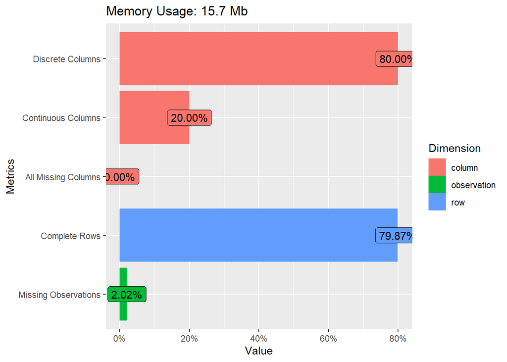

```r
plot_intro(raw_data)
```

lets replace the ‘Not Available’ as missing information in our data set.

```r
raw_data[raw_data=='Not Available']=NA
```

Now lets visualize the missing information in the data

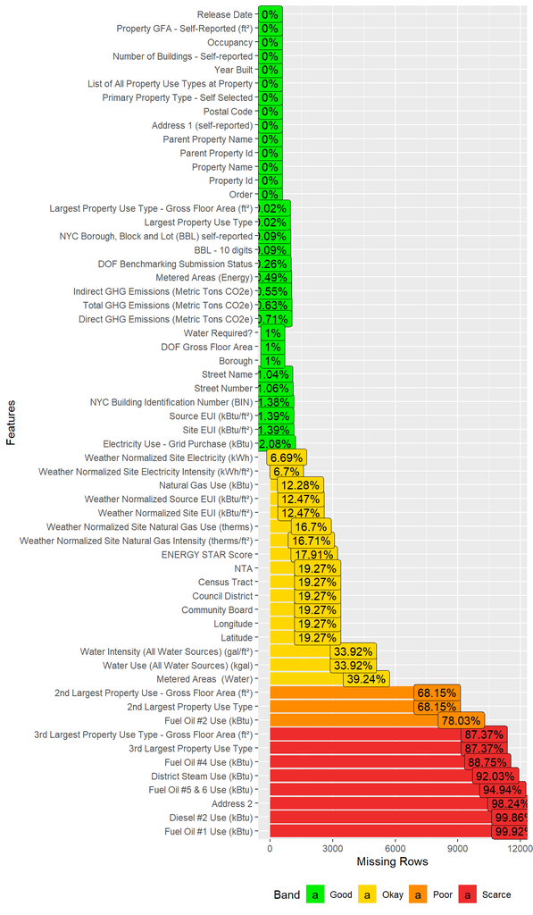

```r
# Custom function
plot_missing_2 <-
function (data, group = list(Good = 0.05, Okay = 0.4, Poor = 0.8,
  Scarce =  1), geom_label_args = list(), title = NULL, ggtheme = theme_gray(),
theme_config = list(legend.position = c("bottom")))
{
  pct_missing <- Band <- NULL
  missing_value <- data.table(profile_missing(data))
  group <- group[sort.list(unlist(group))]
  invisible(lapply(seq_along(group), function(i) {
    if (i == 1) {
      missing_value[pct_missing <= group[[i]], `:=`(Band,
         names(group)[i])]
    } else {
  missing_value[pct_missing > group[[i - 1]] & pct_missing <=
     group[[i]], `:=`(Band, names(group)[i])]
    }
}))
  output <- ggplot(missing_value, aes_string(x = "feature",
    y = "num_missing", fill = "Band")) + geom_bar(stat = "identity") +
   scale_fill_manual("Band", values = c("Good"="green2","Okay"="gold","Poor"="darkorange","Scarce"="firebrick2")) + coord_flip() + xlab("Features") +
   ylab("Missing Rows")
  geom_label_args_list <- list(mapping = aes(label = paste0(round(100 *
    pct_missing, 2), "%")))
  output <- output + do.call("geom_label", c(geom_label_args_list,
     geom_label_args))
  class(output) <- c("single", class(output))
  plotDataExplorer(plot_obj = output, title = title, ggtheme = ggtheme,
   theme_config = theme_config)
}

plot_missing_2(raw_data)
```

There seems to be a lot of missing values we will handle them carefully in our next sections.

# 4 Data Transformation

Here in this section we will be changing the data type of the variables which might have been read as a character/factor variable because of the presence of any unwanted string values but we will also have to be cautious while transforming some of the numeric columns to factors(It might result in a lot of factor levels)–>I mean binning.

```r
datatable(str(raw_data))
```

```
## tibble [11,746 x 60] (S3: spec_tbl_df/tbl_df/tbl/data.frame)
##  $ Order                                                     : num [1:11746] 1 2 3 4 5 6 7 10 11 12 ...
##  $ Property Id                                               : num [1:11746] 13286 28400 4778226 4778267 4778288 ...
##  $ Property Name                                             : chr [1:11746] "201/205" "NYP Columbia (West Campus)" "MSCHoNY North" "Herbert Irving Pavilion & Millstein Hospital" ...
##  $ Parent Property Id                                        : chr [1:11746] "13286" "28400" "28400" "28400" ...
##  $ Parent Property Name                                      : chr [1:11746] "201/205" "NYP Columbia (West Campus)" "NYP Columbia (West Campus)" "NYP Columbia (West Campus)" ...
##  $ BBL - 10 digits                                           : chr [1:11746] "1013160001" "1021380040" "1021380030" "1021390001" ...
##  $ NYC Borough, Block and Lot (BBL) self-reported            : chr [1:11746] "1013160001" "1-02138-0040" "1-02138-0030" "1-02139-0001" ...
##  $ NYC Building Identification Number (BIN)                  : chr [1:11746] "1037549" "1084198; 1084387;1084385; 1084386; 1084388; 1084389; 1807867; 1809824" "1063380" "1087281; 1076746" ...
##  $ Address 1 (self-reported)                                 : chr [1:11746] "201/205  East  42nd  st." "622 168th Street" "3975 Broadway" "161 Fort Washington Ave" ...
##  $ Address 2                                                 : chr [1:11746] NA NA NA "177 Fort Washington Ave" ...
##  $ Postal Code                                               : chr [1:11746] "10017" "10032" "10032" "10032" ...
##  $ Street Number                                             : chr [1:11746] "675" "180" "3975" "161" ...
##  $ Street Name                                               : chr [1:11746] "3 AVENUE" "FT WASHINGTON AVENUE" "BROADWAY" "FT WASHINGTON AVENUE" ...
##  $ Borough                                                   : chr [1:11746] "Manhattan" "Manhattan" "Manhattan" "Manhattan" ...
##  $ DOF Gross Floor Area                                      : num [1:11746] 289356 3693539 152765 891040 211400 ...
##  $ Primary Property Type - Self Selected                     : chr [1:11746] "Office" "Hospital (General Medical & Surgical)" "Hospital (General Medical & Surgical)" "Hospital (General Medical & Surgical)" ...
##  $ List of All Property Use Types at Property                : chr [1:11746] "Office" "Hospital (General Medical & Surgical)" "Hospital (General Medical & Surgical)" "Hospital (General Medical & Surgical)" ...
##  $ Largest Property Use Type                                 : chr [1:11746] "Office" "Hospital (General Medical & Surgical)" "Hospital (General Medical & Surgical)" "Hospital (General Medical & Surgical)" ...
##  $ Largest Property Use Type - Gross Floor Area (ft²)        : chr [1:11746] "293447" "3889181" "231342" "1305748" ...
##  $ 2nd Largest Property Use Type                             : chr [1:11746] NA NA NA NA ...
##  $ 2nd Largest Property Use - Gross Floor Area (ft²)         : chr [1:11746] NA NA NA NA ...
##  $ 3rd Largest Property Use Type                             : chr [1:11746] NA NA NA NA ...
##  $ 3rd Largest Property Use Type - Gross Floor Area (ft²)    : chr [1:11746] NA NA NA NA ...
##  $ Year Built                                                : num [1:11746] 1963 1969 1924 1971 1932 ...
##  $ Number of Buildings - Self-reported                       : num [1:11746] 2 12 1 1 1 12 1 4 1 1 ...
##  $ Occupancy                                                 : num [1:11746] 100 100 100 100 100 100 60 100 100 100 ...
##  $ Metered Areas (Energy)                                    : chr [1:11746] "Whole Building" "Whole Building" NA NA ...
##  $ Metered Areas  (Water)                                    : chr [1:11746] NA "Whole Building" NA NA ...
##  $ ENERGY STAR Score                                         : chr [1:11746] NA "55" NA NA ...
##  $ Site EUI (kBtu/ft²)                                       : chr [1:11746] "305.6" "229.8" NA NA ...
##  $ Weather Normalized Site EUI (kBtu/ft²)                    : chr [1:11746] "303.1" "228.8" NA NA ...
##  $ Weather Normalized Site Electricity Intensity (kWh/ft²)   : chr [1:11746] "37.8" "24.8" NA NA ...
##  $ Weather Normalized Site Natural Gas Intensity (therms/ft²): chr [1:11746] NA "2.4" NA NA ...
##  $ Weather Normalized Source EUI (kBtu/ft²)                  : chr [1:11746] "614.2" "401.1" NA NA ...
##  $ Fuel Oil #1 Use (kBtu)                                    : chr [1:11746] NA NA NA NA ...
##  $ Fuel Oil #2 Use (kBtu)                                    : chr [1:11746] NA "1.96248472E7" NA NA ...
##  $ Fuel Oil #4 Use (kBtu)                                    : chr [1:11746] NA NA NA NA ...
##  $ Fuel Oil #5 & 6 Use (kBtu)                                : chr [1:11746] NA NA NA NA ...
##  $ Diesel #2 Use (kBtu)                                      : chr [1:11746] NA NA NA NA ...
```

[output cut: 69 more lines]

```
##   ..   `Indirect GHG Emissions (Metric Tons CO2e)` = col_character(),
##   ..   `Property GFA - Self-Reported (ft²)` = col_double(),
##   ..   `Water Use (All Water Sources) (kgal)` = col_character(),
##   ..   `Water Intensity (All Water Sources) (gal/ft²)` = col_character(),
##   ..   `Source EUI (kBtu/ft²)` = col_character(),
##   ..   `Release Date` = col_character(),
##   ..   `Water Required?` = col_character(),
##   ..   `DOF Benchmarking Submission Status` = col_character(),
##   ..   Latitude = col_double(),
##   ..   Longitude = col_double(),
##   ..   `Community Board` = col_double(),
##   ..   `Council District` = col_double(),
##   ..   `Census Tract` = col_double(),
##   ..   NTA = col_character()
##   .. )
```

[interactive table not shown]

```r
raw_data<-as.data.frame(raw_data)
cols <- colnames(raw_data[,c(19,21,23,29:51)])
raw_data[cols] <- sapply(raw_data[cols],as.numeric)
raw_data$`ENERGY STAR Score`<-as.numeric(raw_data$`ENERGY STAR Score`)
```

# 5 Insights gathered so far

1. Lets look at the **‘NYC Borough, Block and Lot (BBL) self-reported’**, **‘BBL - 10 digits’** and **‘Borough’** variables.

```r
datatable(raw_data[,c('NYC Borough, Block and Lot (BBL) self-reported','BBL - 10 digits','Borough')])
```

|  | NYC Borough, Block and Lot (BBL) self-reported | BBL - 10 digits | Borough |
| --- | --- | --- | --- |
| 1 | 1013160001 | 1013160001 | Manhattan |
| 2 | 1-02138-0040 | 1021380040 | Manhattan |
| 3 | 1-02138-0030 | 1021380030 | Manhattan |
| 4 | 1-02139-0001 | 1021390001 | Manhattan |
| 5 | 1-02139-0085 | 1021390085 | Manhattan |
| 6 | 1-01480-0001 | 1014800001 | Manhattan |
| 7 | 1-01482-0040 | 1014820040 | Manhattan |
| 8 | 4084890001 | 4084890001 | Queens |
| 9 | 4084890001 | 4084890001 | Queens |
| 10 | 4084890001 | 4084890001 | Queens |

[output cut: 11736 more lines]

2. ‘Address 1 (self-reported)’, ‘Address 2’, ‘Postal Code’,‘Street Name’, ‘Street Number’,‘Latitude’ and ‘Longitude’ contain information about the localization.I’ll keep only ‘Postal Code’ as it seems to be the most generic information about it, besides ‘Borough’. There may be additional or more general information about the location at ‘Census Tract’, ‘Community Board’, ‘Council District’, but for now I’ll ignore these COLUMNS.
3. ‘Total GHG Emissions (Metric Tons CO2e)’=‘Direct GHG Emissions (Metric Tons CO2e)’+‘Indirect GHG Emissions (Metric Tons CO2e)’ — I’ll keep the total and the fraction of direct
4. ‘Property GFA - Self-Reported (ft²)’=‘DOF Gross Floor Area’, so I’ll drop the ‘DOF Gross Floor Area’ that has missing values
5. ‘Largest Property Use Type - Gross Floor Area (ft²)’,‘2nd Largest Property Use - Gross Floor Area (ft²)’ and ‘3rd Largest Property Use Type - Gross Floor Area (ft²)’ are part of ‘Property GFA - Self-Reported (ft²)’– I’ll create and keep the fractions they represent and drop the original values

# 6 Few Feature enginnered columns

## 6.1 Feature Engineering

```r
raw_data<-as.data.frame(raw_data)
raw_data$largest_property_use_rate<-raw_data$`Largest Property Use Type - Gross Floor Area (ft²)`/raw_data$`Property GFA - Self-Reported (ft²)`

raw_data$second_property_use_rate <- raw_data$`2nd Largest Property Use - Gross Floor Area (ft²)`/raw_data$`Property GFA - Self-Reported (ft²)`

raw_data$third_property_use_rate <- raw_data$`3rd Largest Property Use Type - Gross Floor Area (ft²)`/raw_data$`Property GFA - Self-Reported (ft²)`

raw_data$Direct_GHG_Emissions_rate<-raw_data$`Direct GHG Emissions (Metric Tons CO2e)`/raw_data$`Total GHG Emissions (Metric Tons CO2e)`

raw_data[raw_data==""]=NA
raw_data[raw_data==" "]=NA
```

# 7 Missing value treatment

After the transformation and removal of blank spaces from the data, lets see if the missing information has changed from what we observed earlier:

[figure not shown]

```r
plot_missing_2(raw_data)
```

There is a difference meaning there were blank spaces which has resulted in additional missing information in the data.

Lets treat the missing variables which are important to us:

```r
raw_data$Block<-substr(raw_data$`BBL - 10 digits`,2,6)
raw_data$lot<-substr(raw_data$`BBL - 10 digits`,7,10)
```

2. We still have a lot of missing values. Here I will convert some missing values into zero because they are actually zero, transform missing values at 2nd and 3rd Property Use Type to ‘none’ and then drop some of the columns that I believe are irrelevant for the analysis.

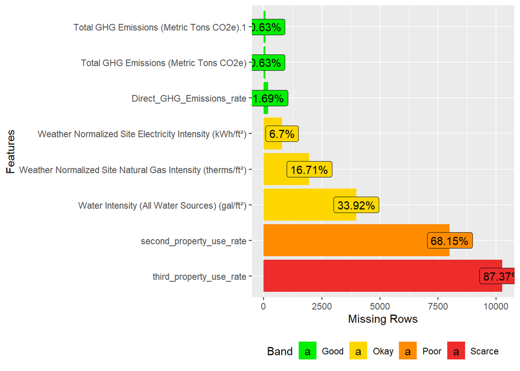

```r
library(tidyr)

zero_col = c('second_property_use_rate','third_property_use_rate','Water Intensity (All Water Sources) (gal/ft²)','Weather Normalized Site Natural Gas Intensity (therms/ft²)','Total GHG Emissions (Metric Tons CO2e)','Weather Normalized Site Electricity Intensity (kWh/ft²)','Direct_GHG_Emissions_rate','Total GHG Emissions (Metric Tons CO2e)')

plot_missing_2(raw_data[zero_col])
```

```r
raw_data<-raw_data %>%
  mutate_at(vars(zero_col), ~replace_na(., 0))

prop_col = c('2nd Largest Property Use Type','3rd Largest Property Use Type')

raw_data<-raw_data %>%
  mutate_at(vars(prop_col), ~replace_na(., 'none'))
```

```r
columns_to_drop = c('NYC Borough, Block and Lot (BBL) self-reported',
            'NYC Building Identification Number (BIN)',
            'BBL - 10 digits',
            'Parent Property Name',
            'Property Name',
            'Address 1 (self-reported)',
            'Address 2',
            'Street Number',
            'Street Name',
            'Latitude',
            'Longitude',
            'DOF Gross Floor Area',
            'DOF Benchmarking Submission Status',
            'List of All Property Use Types at Property',
            'Largest Property Use Type - Gross Floor Area (ft²)',
            '2nd Largest Property Use - Gross Floor Area (ft²)',
            '3rd Largest Property Use Type - Gross Floor Area (ft²)',
            'Fuel Oil #1 Use (kBtu)',
            'Fuel Oil #2 Use (kBtu)',
            'Fuel Oil #4 Use (kBtu)',
            'Fuel Oil #5 & 6 Use (kBtu)',
            'Diesel #2 Use (kBtu)',
            'District Steam Use (kBtu)',
            'Natural Gas Use (kBtu)',
            'Weather Normalized Site Natural Gas Use (therms)',
            'Electricity Use - Grid Purchase (kBtu)',
            'Weather Normalized Site Electricity (kWh)',
            'Direct GHG Emissions (Metric Tons CO2e)',
            'Indirect GHG Emissions (Metric Tons CO2e)',
            'Property GFA - Self-Reported (ft²)',
            'Water Use (All Water Sources) (kgal)',
            'Weather Normalized Site EUI (kBtu/ft²)',
            'Weather Normalized Source EUI (kBtu/ft²)')

raw_data1<-raw_data[!colnames(raw_data)%in%columns_to_drop]
```

# 8 Binning Property type variable